# Theming: Customizing plots

Elizabeth King

Kevin Middleton

## What can you customize?

(Nearly) everything.

## Blank slate

There is a ggplot here:

```r
ggplot() +
  theme_void()
```

## `gg`this and `gg`that

- Lots of packages have plotting functionality built on top of `ggplot`
- Not all play nicely with regular `ggplot` theme elements
  - Can’t `+` elements, etc.
  - Your mileage may vary

## Scales

`scale_` handles changing how aesthetics are represented in plots

- `scale_x_`
- `scale_y_`
- `scale_color_`
- `scale_fill_`
- `scale_shape_`
- etc.

## Types of scales

`scale_`aesthetic`_`type where type is

- `continuous`
- `discrete`
- `manual`
- `date`, `time`, `datetime`
- etc.

Different aesthetics have different scale types available

- RStudio tab completion is your friend here: `scale_x`-Tab

## `scale_x_` and `scale_y_`

Most commonly:

- `scale_{xy}_continuous`: Continuous
- `scale_{xy}_discrete`: Categorical
- `scale{xy}_log10`: log<sub>10</sub> transformation
- `scale{xy}_sqrt`: Square-root transformation
- `scale{xy}_manual`: Manually specify parameters (e.g., color)

## Electric fish diversity and tributaries

Species abundance of electric fish upstream and downstream of the entrance of a tributary in the Amazon basin.

| Tributary | n_Upstream | n_Downstream |
| --- | --- | --- |
| Coari | 5 | 7 |
| Ica | 14 | 19 |
| Japura | 8 | 8 |
| Jutai | 11 | 18 |
| Madeira | 29 | 30 |
| Manacapuru | 5 | 6 |
| Negro | 23 | 24 |
| Purus | 10 | 16 |
| Tapajos | 16 | 20 |
| Tocantins | 10 | 12 |
| Trombetas | 19 | 16 |
| Xingu | 25 | 21 |

## Electric fish visualization

1. Bar plot of `n_Upstream` and `n_Downstream` diversity by `Tributary`
2. Scatter plot of `n_Upstream` vs. `n_Downstream`

## Bar plot

- Code
- Plot

```r
EF_bar <- EF |>
  pivot_longer(cols = -Tributary,
               names_to = "Up_Down",
               values_to = "n_Species") |>
  ggplot(aes(x = Tributary,
             y = n_Species,
             fill = Up_Down,
             group = Up_Down)) +
  geom_bar(stat = "identity",
           position = position_dodge(width = 0.9))
```

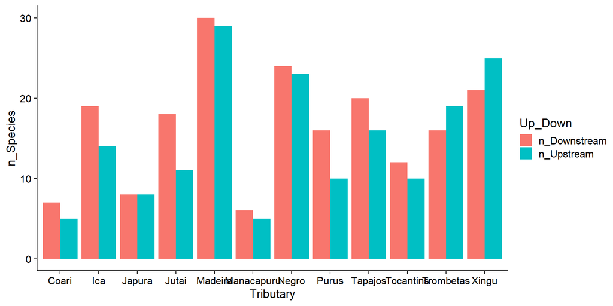

## Bar plot refinements

- Code
- Plot
- `ggplot`s are additive, so we can “add” to an existing plot.
- Change axis limits (but see *Ethics in visualization*)
- Two ways to change axis labels

```r
EF_bar <- EF_bar +
  scale_y_continuous(limits = c(0, 50),
                     breaks = seq(0, 50, by = 5)) +
  scale_x_discrete(name = "Upstream/Downstream") +
  labs(y = "Number of Species",
       title = "Species Diversity in the Amazon")
```

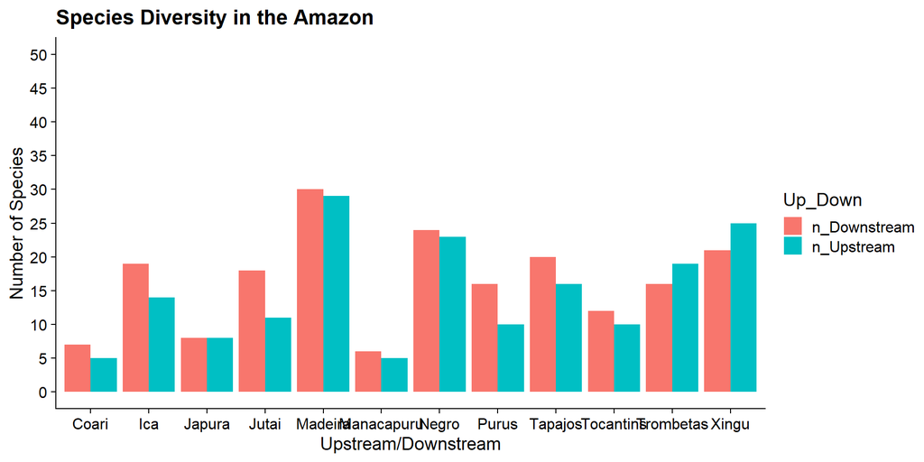

## Scatter plot

- Code
- Plot

What is the relationship between upstream and downstream diversity?

```r
EF_scatter <- ggplot(EF, aes(x = n_Upstream,
                             y = n_Downstream)) +
  geom_point()
```

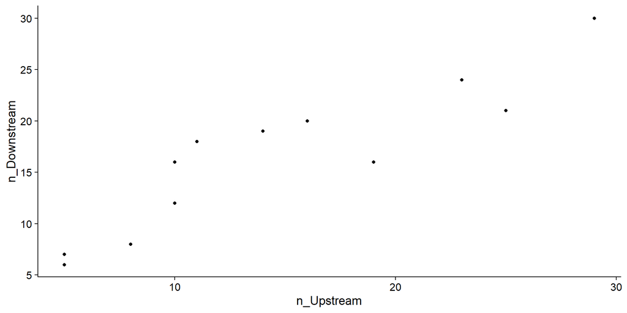

## Scatter plot refinements

- Code
- Plot
- Add a straight line with a slope of 1
- Change the color and size of all points

```r
EF_scatter <- ggplot(EF, aes(x = n_Upstream,
                             y = n_Downstream)) +
  geom_abline(slope = 1, intercept = 0, linetype = "dotted") +
  geom_point(color = "tomato", size = 3)
```

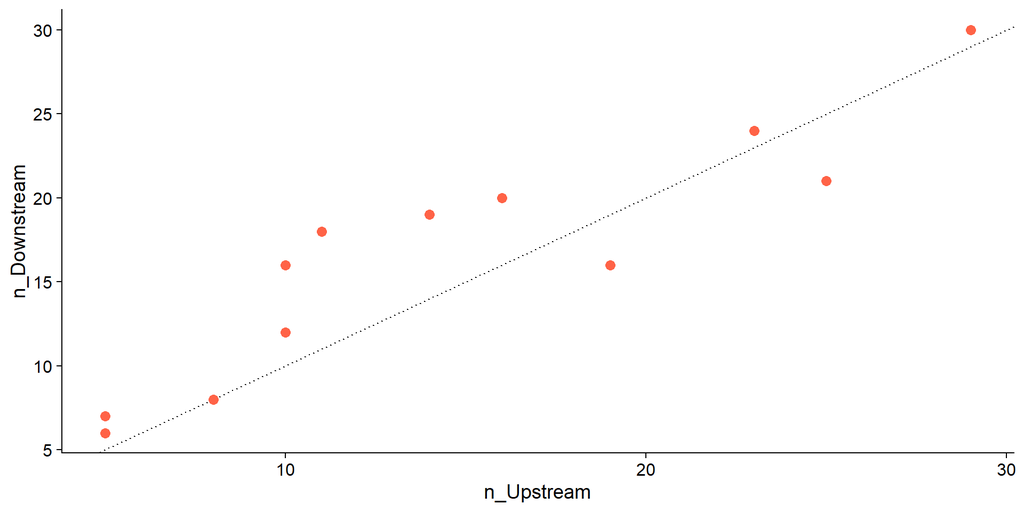

## Changing axis aspect ratio

- Code
- Plot
- Make the plot square (`coord_equal`)
- Set the axis ranges to be equal (`xlim`, `ylim`)

```r
EF_scatter <- EF_scatter +
  coord_equal(xlim = c(0, 30), ylim = c(0, 30))
```

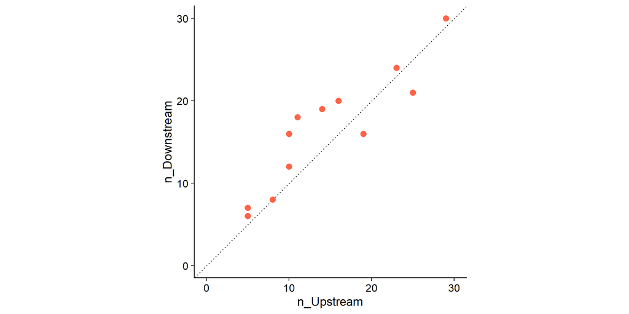

## `scale_color_` and `scale_fill_`

- Code
- Plot
- Set the fill manually
- Include a line break in the legend title string with `\n`

```r
EF_bar_m <- EF_bar +
  scale_fill_manual(values = c("orange", "darkgreen"),
                    name = "Upstream /\nDownstream")
```

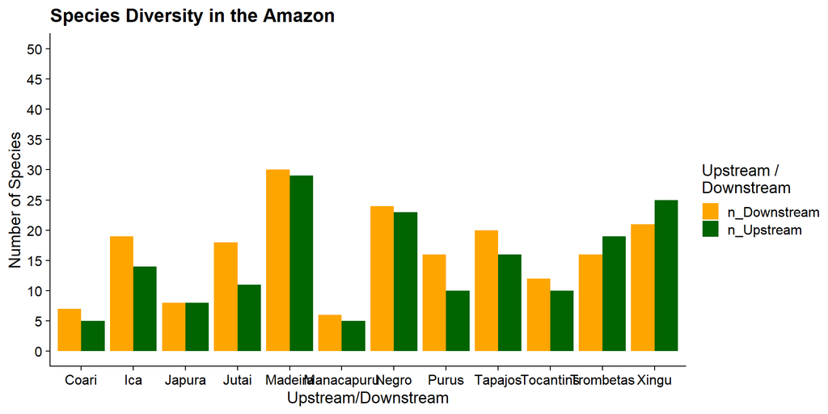

## Automated color and fill scales

- Code
- Plot
- [RColorBrewer](https://colorbrewer2.org/)
- [viridis](https://cran.r-project.org/web/packages/viridis/vignettes/intro-to-viridis.html)
- [paletteer](https://emilhvitfeldt.github.io/paletteer/)

```r
EF_bar_b <- EF_bar +
  scale_fill_brewer(type = "qual")
```

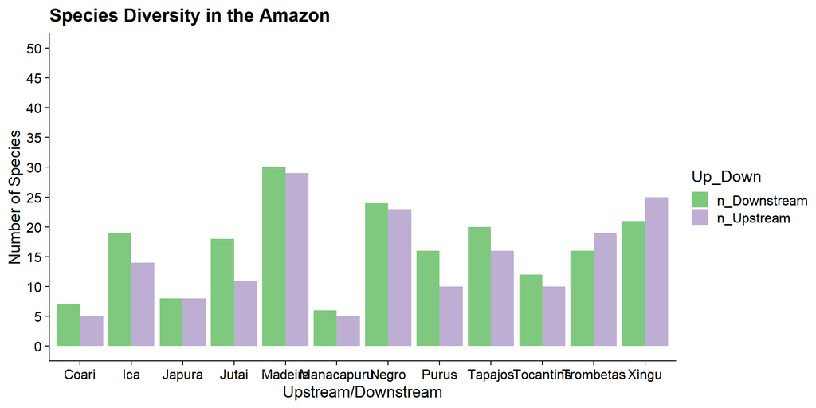

## `scale_shape_`

- ggplot inherits the standard set of R point shapes
- [Point shapes in R](https://r-graphics.org/recipe-scatter-shapes)

## `scale_size_`

- Code
- Plot
- [Size by area (default) or radius](https://ggplot2-book.org/scale-other.html)
- Set the `range` to control the output scale

```r
EF_size <- EF |>
  pivot_longer(cols = -Tributary,
               names_to = "Up_Down",
               values_to = "n_Species") |>
  ggplot(aes(x = Tributary,
             y = Up_Down,
             label = n_Species,
             size = n_Species)) +
  geom_point(alpha = 0.25) +
  geom_text() +
  scale_size(range = c(1, 10))
```

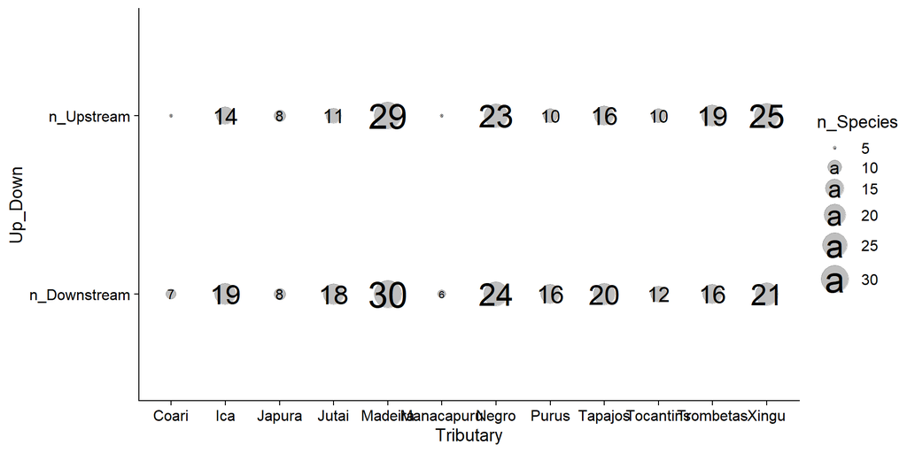

## `theme()` changes aspects of plots

- Fully custom and reusing themes in a few weeks
- See `?theme` for options
- [ggplot book has many examples](https://ggplot2-book.org/polishing.html)

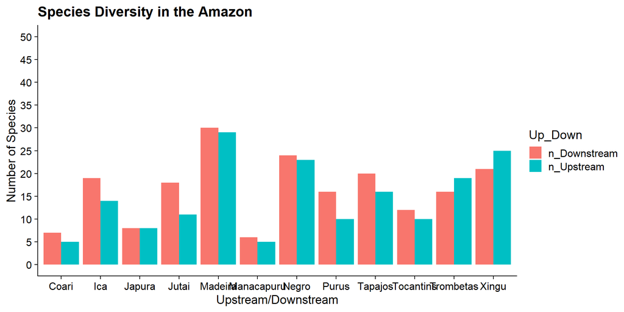

## Changing axis components

- Code
- Plot

```r
EF_bar <- EF_bar +
  labs(x = "Stream") +
  scale_fill_manual(values = c("darkred", "navy"),
                    name = "Location",
                    labels = c("Downstream", "Upstream")) +
  theme(axis.text = element_text(size = 9),
        axis.text.x = element_text(angle = 90, vjust = 0.5, hjust = 1),
        axis.title.y = element_text(face = "bold"),
        axis.title.x = element_blank(),
        legend.title = element_text(size = 10, face = "italic"),
        legend.text = element_text(size = 9))
```

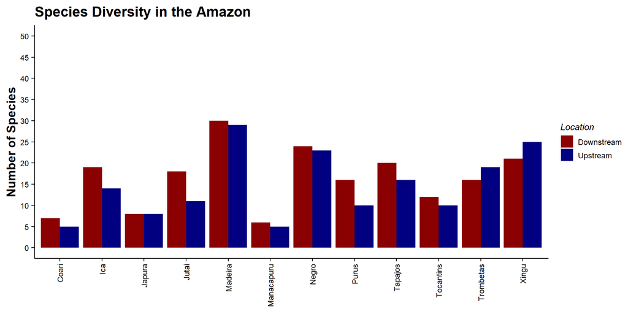

## (Re)moving and reshaping the legend

- Code
- Plot
- Remove the legend

```r
EF_size <- EF_size +
  theme(legend.position = "none")
```

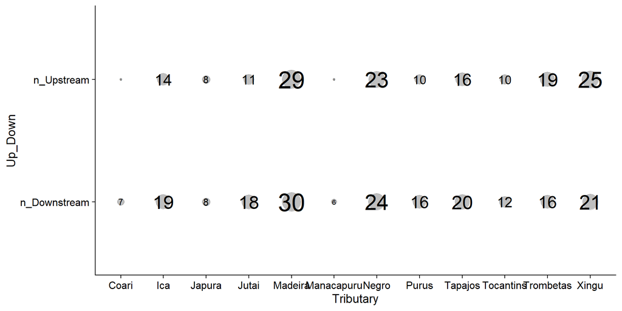

## Customizing the legend

- Code
- Plot

```r
EF_scatter <- ggplot(EF, aes(x = n_Upstream,
                             y = n_Downstream,
                             color = Tributary)) +
  geom_abline(slope = 1, intercept = 0, linetype = "dotted") +
  geom_point(size = 5) +
  scale_color_viridis_d(guide = guide_legend(ncol = 3,
                                             override.aes = list(size = 2))) +
  coord_equal(xlim = c(0, 30), ylim = c(0, 30)) +
  labs(x = "Upstream Species",
       y = "Downstream Species",
       title = "Species Diversity in the Amazon") +
  theme(legend.title = element_text(size = 10),
        legend.text = element_text(size = 9),
        legend.position = c(0.35, 0.175),
        legend.box.background = element_rect(color = "black", size = 1),
        legend.box.margin = margin(4, 4, 4, 4),
        axis.title = element_text(face = "bold"))
```

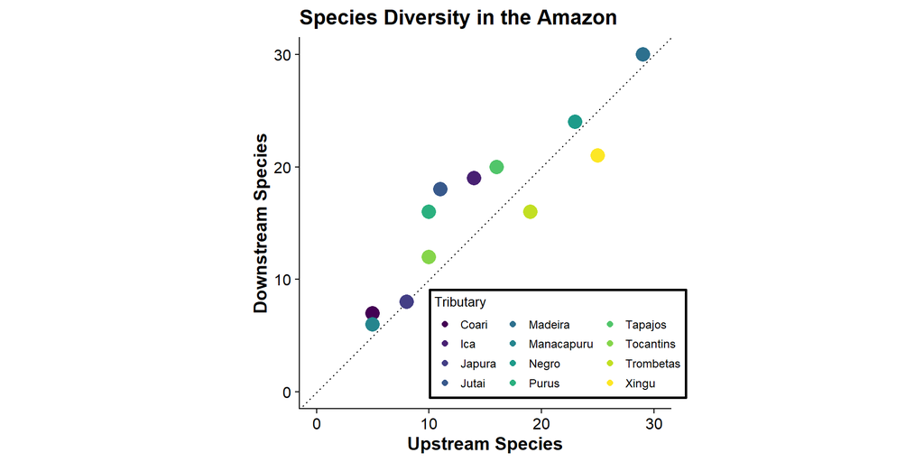

## Using `element_blank()` to remove plot elements

```r
EF_bar_blank <- EF_bar +
  scale_y_continuous(expand = c(0, 0)) +
  theme(axis.ticks.x = element_blank(),
        axis.line.x = element_blank())
```

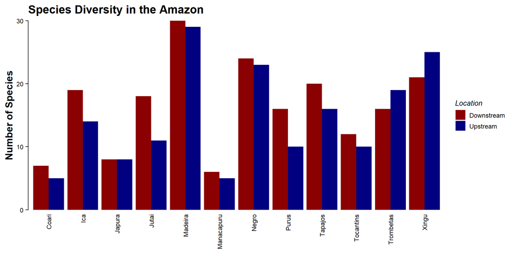

[figure not shown]